# Economic Indicators and relationship with well being

Economic indicator, such as GDP and GDP per capita, not only show a country’s economic performance as a whole as well as on an individual level. They are also strongly correlated with other important figures e.g., life expectancy, personal well-being and, to a lesser degree, with one’s happiness. In the following diagrams we will be showing the correlation between GDP / GDP per capita and before mentioned social economic indices.

```r
# load the required libraries and datasets
knitr::opts_chunk$set(echo = TRUE, message= FALSE, warning= FALSE)
library(reticulate)
library("sf")
library("rnaturalearth")
library("rnaturalearthdata")
library(tidyverse)
library(countrycode)
library(plotly)
library(broom)
library(purrr)
library(ggthemes)
library(countrycode)
library(tmap)

data("World")
load("worldbankindicators.RData")
```

```r
### manipulation of the datasets for further usage
# change country code in the World dataset with countrycode()
World$iso2c=countrycode(sourcevar = World$iso_a3,
                        origin = "iso3c",
                        destination = "iso2c")
# average of the indicators (inflation, GDP, Interest rate, Population, Unemployment) from the worldbank dataset
averaged_data <- worldbank_data%>%
  group_by(iso2c, country, Indicator)%>%
  summarise(Values=mean(Values,na.rm=T))
# filter by the most recent year, named here as 'current_data'
current_data <- worldbank_data %>%
  filter(year==2000)

# join 'World' dataset with worldbank dataset
joined_data <- World%>%left_join(current_data, by='iso2c')

# filter only for inflation and unemployment
inflation <- filter(joined_data, Indicator=='Inflation')
unemployment <- filter(joined_data, Indicator =='Unemployment')
```

```
Warning: Removed 171 rows containing non-finite values (stat_smooth).
Warning: Removed 171 rows containing missing values (geom_point).
```

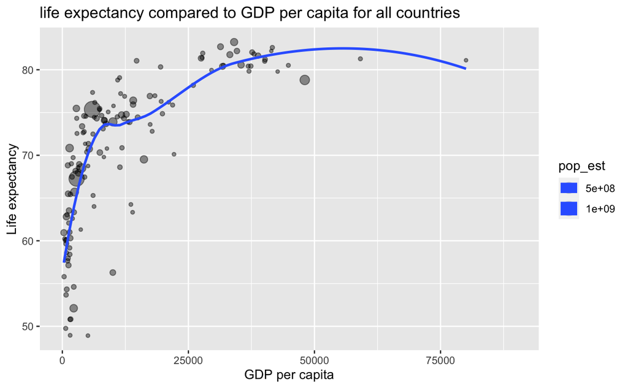

```r
joined_data %>%
  filter(continent %in% c('Asia', 'Africa', 'Europe', 'South America', 'Oceania', 'North America')) %>%
  ggplot(aes(x = (gdp_cap_est),
             y = (life_exp),
             size= pop_est,
             )) +
  geom_point(alpha=0.1) +
  xlim(0,90000) +
  geom_smooth(se=F)+
  #facet_wrap(~continent)+
  labs(title='life expectancy compared to GDP per capita for all countries',
       x = 'GDP per capita',
       y = 'Life expectancy',
       colour = 'continent')
```

The positive relationship between life expectancy and GDP per capita can be clearly seen here. The jump in life expectancy is especially strong below the 25000$ threshold. After that the relationship starts to flatten.

```
Warning: Removed 176 rows containing non-finite values (stat_smooth).
Warning: Removed 176 rows containing missing values (geom_point).
```

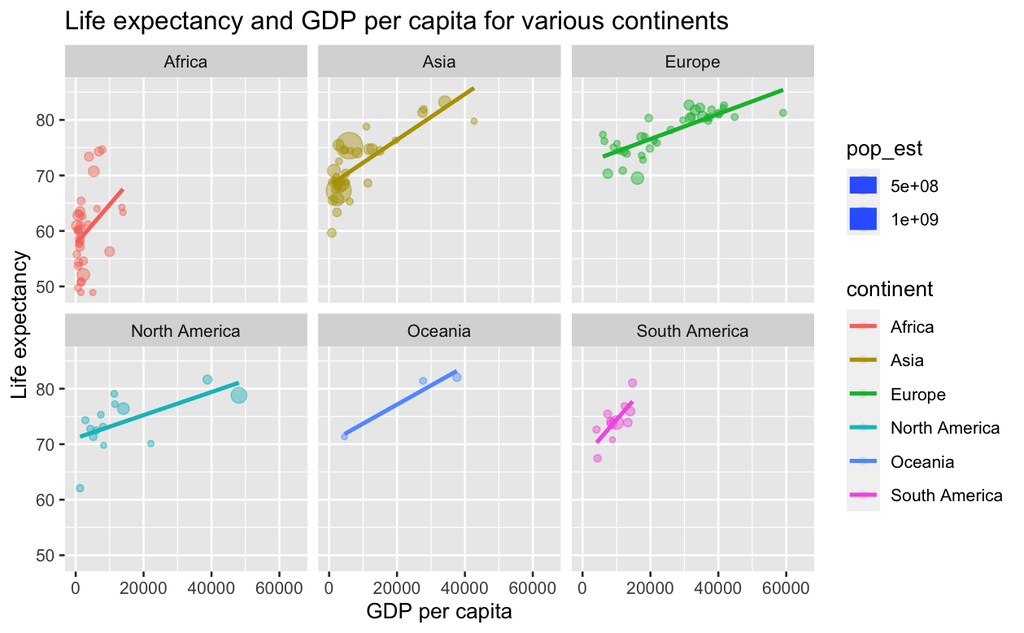

```r
# life expectancy vs GDP per capita for each continent
joined_data %>%
  filter(continent %in% c('Asia', 'Africa', 'Europe', 'South America', 'Oceania', 'North America')) %>%
  ggplot(aes(x = (gdp_cap_est),
             y = (life_exp),
             size= pop_est,
             color=continent
  )) +
  geom_point(alpha = 0.1)+
  xlim(0,65000) +
  geom_smooth(method=lm, se=F)+
  facet_wrap(~continent)+
  labs(title='Life expectancy and GDP per capita for various continents',
       x = 'GDP per capita',
       y = 'Life expectancy',
       colour = 'continent')
```

When the continents observed individually, one could argue the positive relationship between those two variables are stronger in the developing nations than in the already developed nations.

```
Warning: Removed 173 rows containing non-finite values (stat_smooth).
Warning: Removed 173 rows containing missing values (geom_point).
```

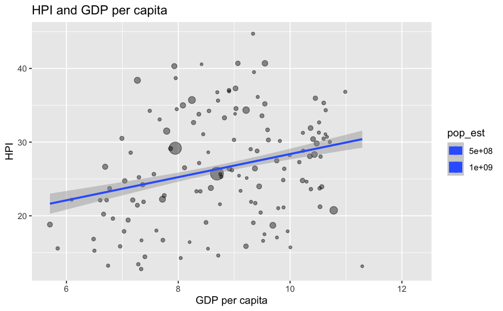

```r
# HPI and GDP per capita for all countries
joined_data %>%
  ggplot(aes(x = log(gdp_cap_est),
             y = HPI,
             size= pop_est,
  )) +
  geom_point(alpha = 0.1)+
  geom_smooth(method=lm, se=T)+
  labs(title='HPI and GDP per capita',
       x = 'GDP per capita',
       y = 'HPI',
       colour = 'continent')
```

Background information on HPI: HPI - The happy planet index consists of human well-being and its environmental impact. It can be described as an average of subjective life satisfaction, life expectancy at birth and ecological footprint per capita. In contrast to GDP and HDI （Human development index) it takes sustainability into account. The HPI was first introduced by 2006. Well-being, as the name suggests, is defined as what is ultimately good for a single individual, it is in the self-interest of the individual. The well-being index is developed by Mayo Clinic as an anonymous tool to allow participants to assess one’s well-being on various dimensions including ‘quality of life’, ‘meaning of work’, ‘likelihood of burnout, ‘suicidal ideation’ and more.